# 2024 SOE stock status indicator

Sarah Gaichas

13 December, 2023

# Major Takeaway

## Pull from `stocksmart` for 2024 SOE reports

Andy renamed the assessmentdata package [stocksmart](https://noaa-edab.github.io/stocksmart/) based on [Stock SMART](https://www.st.nmfs.noaa.gov/stocksmart?app=homepage).

Two data frames are in the package, `stockAssessmentData` and `stockAssessmentSummary`.

In `stockAssessmentData` we have time series. Columns are StockName, Stockid, Assessmentid, Year, Value, Metric, Description, Units, AssessmentYear, Jurisdiction, FMP, CommonName, ScientificName, ITIS, AssessmentType, StockArea, RegionalEcosystem and the reported metrics are Catch, Fmort, Recruitment, Abundance, Index.

```r
datatable(head(stockAssessmentData), rownames = FALSE)
```

| StockName | Stockid | Assessmentid | Year | Value | Metric | Description | Units | AssessmentYear | Jurisdiction | FMP | CommonName | ScientificName | ITIS | AssessmentType | StockArea | RegionalEcosystem |
| --- | --- | --- | --- | --- | --- | --- | --- | --- | --- | --- | --- | --- | --- | --- | --- | --- |
| Acadian redfish - Gulf of Maine / Georges Bank | 10455 | 12882 | 1913 | 7 | Catch | Reported Catch - Total (Mean) | Metric Tons | 2023 | NEFMC | Northeast Multispecies | Acadian redfish | Sebastes fasciatus | 166774 | Operational | Gulf of Maine / Georges Bank | Northeast Shelf |
| Acadian redfish - Gulf of Maine / Georges Bank | 10455 | 12882 | 1914 | 30 | Catch | Reported Catch - Total (Mean) | Metric Tons | 2023 | NEFMC | Northeast Multispecies | Acadian redfish | Sebastes fasciatus | 166774 | Operational | Gulf of Maine / Georges Bank | Northeast Shelf |
| Acadian redfish - Gulf of Maine / Georges Bank | 10455 | 12882 | 1915 | 40 | Catch | Reported Catch - Total (Mean) | Metric Tons | 2023 | NEFMC | Northeast Multispecies | Acadian redfish | Sebastes fasciatus | 166774 | Operational | Gulf of Maine / Georges Bank | Northeast Shelf |
| Acadian redfish - Gulf of Maine / Georges Bank | 10455 | 12882 | 1916 | 53 | Catch | Reported Catch - Total (Mean) | Metric Tons | 2023 | NEFMC | Northeast Multispecies | Acadian redfish | Sebastes fasciatus | 166774 | Operational | Gulf of Maine / Georges Bank | Northeast Shelf |
| Acadian redfish - Gulf of Maine / Georges Bank | 10455 | 12882 | 1917 | 82 | Catch | Reported Catch - Total (Mean) | Metric Tons | 2023 | NEFMC | Northeast Multispecies | Acadian redfish | Sebastes fasciatus | 166774 | Operational | Gulf of Maine / Georges Bank | Northeast Shelf |
| Acadian redfish - Gulf of Maine / Georges Bank | 10455 | 12882 | 1918 | 73 | Catch | Reported Catch - Total (Mean) | Metric Tons | 2023 | NEFMC | Northeast Multispecies | Acadian redfish | Sebastes fasciatus | 166774 | Operational | Gulf of Maine / Georges Bank | Northeast Shelf |

In `stockAssessmentSummary` we have assessment metadata. Columns are Stock ID, Stock Name, Jurisdiction, FMP, Science Center, Regional Ecosystem, FSSI Stock?, ITIS Taxon Serial Number, Scientific Name, Common Name, Stock Area, Assessment ID, Assessment Year, Assessment Month, Last Data Year, Review Result, Assessment Model, Model Version, Lead Lab, Citation, Final Assessment Report 1, Final Assessment Report 2, Point of Contact, Life History Data, Abundance Data, Catch Data, Assessment Level, Assessment Frequency, Model Category, Catch Input Data, Abundance Input Data, Biological Input Data, Ecosystem Linkage, Composition Input Data, F Year, Estimated F, F Unit, F Basis, Flimit, Flimit Basis, Fmsy, Fmsy Basis, F/Flimit, F/Fmsy, Ftarget, Ftarget Basis, F/Ftarget, B Year, Estimated B, B Unit, B Basis, Blimit, Blimit Basis, Bmsy, Bmsy Basis, B/Blimit, B/Bmsy, MSY, MSY Unit, Assessment Type.

```r
datatable(head(stockAssessmentSummary), rownames = FALSE, options = list(scrollX = TRUE))
```

| Stock ID | Stock Name | Jurisdiction | FMP | Science Center | Regional Ecosystem | FSSI Stock? | ITIS Taxon Serial Number | Scientific Name | Common Name | Stock Area | Assessment ID | Assessment Year | Assessment Month | Last Data Year | Review Result | Assessment Model | Model Version | Lead Lab | Citation | Final Assessment Report 1 | Final Assessment Report 2 | Point of Contact | Life History Data | Abundance Data | Catch Data | Assessment Level | Assessment Frequency | Model Category | Catch Input Data | … |
| --- | --- | --- | --- | --- | --- | --- | --- | --- | --- | --- | --- | --- | --- | --- | --- | --- | --- | --- | --- | --- | --- | --- | --- | --- | --- | --- | --- | --- | --- | --- |
| 11089 | Atlantic menhaden - Atlantic Coast | ASMFC | ASMFC Not In FMP | NEFSC / SEFSC | Northeast Shelf / Southeast Shelf | N | 161732 | Brevoortia tyrannus | Atlantic menhaden | Atlantic Coast | 9509 | 2020 | 1 | 2017 | Full acceptance | BAM | Atlantic Menhaden | Beaufort Lab |  | SEDAR 69 Benchmark Stock Assessment Report Atlantic Menhaden |  | melissa.karp@noaa.gov |  |  |  |  |  | 6 | 5 | … |
| 11089 | Atlantic menhaden - Atlantic Coast | ASMFC | ASMFC Not In FMP | NEFSC / SEFSC | Northeast Shelf / Southeast Shelf | N | 161732 | Brevoortia tyrannus | Atlantic menhaden | Atlantic Coast | 12496 | 2022 | 11 | 2021 | Full acceptance | BAM | Atlantic Menhaden | Beaufort Lab |  | 2022�Atlantic�Menhaden�Stock�Assessment�Update� |  | Amy.Schueller@noaa.gov |  |  |  |  |  | 6 | 5 | … |
| 10950 | Albacore - North Atlantic | Atlantic HMS | Consolidated Atlantic Highly Migratory Species | SEFSC | Atlantic Highly Migratory | N | 172419 | Thunnus alalunga | Albacore | North Atlantic | 936 | 2007 | 7 | 2005 | Full acceptance | MultifanCL |  | ICCAT-SCRS | http://www.iccat.int/Documents/Meetings/Docs/2007_ALB%20STOCK%20ASSESS%20REP_AUG_07.pdf | REPORT OF THE 2007 ICCAT ALBACO RE STOCK ASSESSMENT SESSION |  | Victor Restrepo | 2 | 1 | 2 | 4 | 2 |  |  | … |
| 10950 | Albacore - North Atlantic | Atlantic HMS | Consolidated Atlantic Highly Migratory Species | SEFSC | Atlantic Highly Migratory | N | 172419 | Thunnus alalunga | Albacore | North Atlantic | 2245 | 2009 | 10 | 2007 | Full acceptance | Multifan CL |  | ICCAT-SCRS | http://www.iccat.int/Documents/Meetings/Docs/2009_ALB_ASSESS_ENG.pdf | REPORT OF THE 2009 ICCAT ALBACO RE STOCK ASSESSMENT SESSION |  | Michael Schirripa, Craig Brown | 2 | 1 | 2 | 4 | 2 |  |  | … |
| 10950 | Albacore - North Atlantic | Atlantic HMS | Consolidated Atlantic Highly Migratory Species | SEFSC | Atlantic Highly Migratory | N | 172419 | Thunnus alalunga | Albacore | North Atlantic | 3895 | 2013 | 10 | 2011 | Full acceptance | Multifan CL |  | ICCAT-SCRS | http://www.iccat.int/Documents/Meetings/Docs/2013_ALB_ASSESS_REP_ENG.pdf |  |  | Michael Schirripa, Craig Brown | 3 | 1 | 2 | 4 | 2 |  |  | … |
| 10950 | Albacore - North Atlantic | Atlantic HMS | Consolidated Atlantic Highly Migratory Species | SEFSC | Atlantic Highly Migratory | N | 172419 | Thunnus alalunga | Albacore | North Atlantic | 6935 | 2016 | 10 | 2015 | Full acceptance | Aspic |  | ICCAT-SCRS | http://iccat.es/Documents/Meetings/Docs/2016_ALB_REPORT_ENG.pdf | Albacore 2016 Assessment Report |  | Rishi Sharma, Craig Brown | 3 | 1 | 1 | 3 | 2 |  |  | … |

Build ecodata input spreadsheet from `stockAssessmentSummary` and use the ecodata code to make the dataset for plotting:

```r
assess2023 <- stockAssessmentSummary %>%
  filter(`Science Center` == "NEFSC") %>%
  select(c(`Stock Name`, Jurisdiction, FMP, `Science Center`,
           `Stock Area`, `Assessment Year`, `Last Data Year`,
           `F Year`, `Estimated F`, Flimit, Fmsy, `F/Flimit`,
           `F/Fmsy`, Ftarget, `F/Ftarget`, `B Year`, `Estimated B`,
           `B Unit`, Blimit, Bmsy, `B/Blimit`, `B/Bmsy`)) %>%
  arrange(Jurisdiction, `Stock Name`, FMP, `Assessment Year`) %>%
  rename(Entity.Name = `Stock Name`,
         Assessment.Year = `Assessment Year`,
         F.Fmsy = `F/Fmsy`,
         B.Bmsy = `B/Bmsy`,
         Estimated.F = `Estimated F`,
         Estimated.B = `Estimated B`)

write.csv(assess2023, here("assess.csv"))

# from get_stocks.R, ecodata 2020
  #assess <- read.csv(file.path(data.dir, "2019assess.csv"))
  assess <- assess2023
  #decode <- read.csv(file.path(data.dir, "2019decoder.csv"))
  decode <- read.csv(here("2020decoder.csv"))

write.csv(decode, here("decoder.csv"))

stock_status_stockSMART <-
    assess %>%
    dplyr::group_by(Entity.Name) %>%
    dplyr::filter(Assessment.Year == max(Assessment.Year)) %>%
  #Find last year assessment occurred for each stock
    dplyr::ungroup() %>%
    dplyr::left_join(.,decode, by = "Entity.Name") %>% #Join in list of managed species
    dplyr::select(Entity.Name, Assessment.Year, F.Fmsy, B.Bmsy, Council, Code) %>%
  #select column variables to keep
    dplyr::mutate(id = 1:length(Entity.Name)) %>%
    tidyr::gather(.,Var, Value,-id,-Entity.Name,-Assessment.Year,-Council,-Code) %>%
  #wide to long
    dplyr::select(-id) %>%
    dplyr::rename(`Last assessment` = Assessment.Year,
                  Stock = Entity.Name) %>% #rename variables for clarity
    dplyr::mutate(Units = "unitless") #%>%
    #dplyr::mutate(Value = replace(Value, which(Code == "N Windowpane" & Var == "F.Fmsy"), NA))
```

Then test to see if we see the updates relative to SOE 2023 (updates through 2022) ecodata. I’m leaving out all the plot annotations for unknown status.

### Comparisons

#### StockSMART Oct 2023 source, Mid-Atlantic

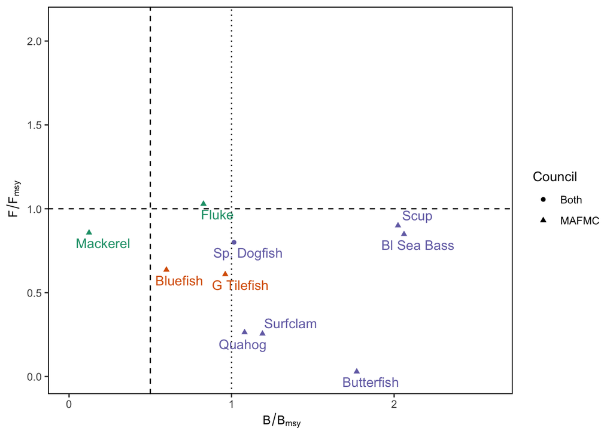

```r
stock_status <-
  stock_status_stockSMART %>%
  mutate(Code = recode(Code, "Dogfish" = "Sp. Dogfish" )) %>%
  spread(.,Var,Value) %>%
  filter(Council %in% c("MAFMC","Both")) %>%
  group_by(Stock) %>%
  mutate(score = case_when(
    (B.Bmsy <0.5) ~"a",
    (F.Fmsy >1) ~ "a",
    (F.Fmsy < 1 & B.Bmsy > 0.5 & B.Bmsy < 1) ~ "b",
    (F.Fmsy < 1 & B.Bmsy > 1) ~ "c"))
#Plot constants
y.max <- 2.1 #2.0 mackerel cut off F/Fmsy is 2.08
x.max <- 2.6
#A dataframe that defines custom legend for stocks with unknown status
# unknown <- data.frame(text = c("Unknown Status", "Longfin Squid",
#                               "Shortfin Squid", "N. Goosefish", "S. Goosefish"),
#                     x = rep(0.9*x.max,5), y = seq(0.93*y.max,1.5,-.1))

# Custom Color
custom_color<- c("#56B4E9", "#009E73", "#0072B2")
#Plotting code
ggplot(data = stock_status) +
  geom_vline(xintercept = 1, linetype = "dotted")+
  geom_vline(xintercept = 0.5, linetype = "dashed")+
  geom_hline(yintercept = 1, linetype = "dashed") +
  geom_point(aes(x = B.Bmsy,
                 y = F.Fmsy,
                 shape = Council,
                 color = score)) +
  geom_text_repel(aes(x = B.Bmsy, #geom_text_repel auto-jitters text around points
                      y = F.Fmsy,
                      label = Code,
                      color = score),
                  show.legend = FALSE, nudge_y = -0.01, nudge_x = 0.05) +
  scale_color_brewer(palette = "Dark2",
                     breaks = stock_status$score) +
  ylim(0,y.max) +
  xlim(0,x.max) +
  # geom_text(data = unknown, aes(x = x, y = y, label = text), #Custom legend for unknown stock status
  #           size = c(4.75,rep(4,4))) +
  # annotate("rect", xmin = 0.8*x.max,
  #          xmax = x.max,
  #          ymin = 0.65*y.max,
  #          ymax = 0.90*y.max,
  #          alpha = 0.1) +
  xlab(expression(~B/B[msy])) +
  ylab(expression(~F/F[msy])) +
  guides(color = FALSE) +
  theme_ts()
```

#### SOE 2023 ecodata source, Mid-Atlantic

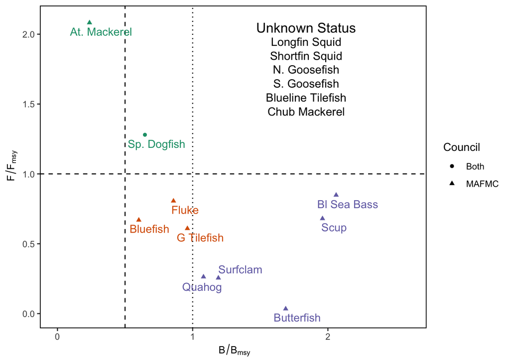

```r
#Get data, spread for plotting, and filter
stock_status <- ecodata::stock_status %>%
  dplyr::mutate(Code = recode(Code, "Dogfish" = "Sp. Dogfish" ),
                Code = recode(Code, "Mackerel" = "At. Mackerel")) %>%
  tidyr::spread(.,Var,Value) %>%
  dplyr::filter(Council %in% c("MAFMC","Both")) %>%
  dplyr::group_by(Stock) %>%
  dplyr::mutate(score = case_when(
    (B.Bmsy <0.5) ~"a",
    (F.Fmsy >1) ~ "a",
    (F.Fmsy < 1 & B.Bmsy > 0.5 & B.Bmsy < 1) ~ "b",
    (F.Fmsy < 1 & B.Bmsy > 1) ~ "c"))
#Plot constants
y.max <- 2.1 #1.75 mackerel cut off F/Fmsy is 1.8
x.max <- 2.6
#A dataframe that defines custom legend for stocks with unknown status
unknown <- data.frame(text = c("Unknown Status", "Longfin Squid",
                              "Shortfin Squid", "N. Goosefish", "S. Goosefish", "Blueline Tilefish", "Chub Mackerel"),
                    x = rep(0.9*x.max,7), y = seq(0.88*y.max,1.2,-0.1))

# Custom Color
custom_color<- c("#56B4E9", "#009E73", "#0072B2")
#Plotting code
ggplot2::ggplot(data = stock_status) +
  ggplot2::geom_vline(xintercept = 1, linetype = "dotted")+
  ggplot2::geom_vline(xintercept = 0.5, linetype = "dashed")+
  ggplot2::geom_hline(yintercept = 1, linetype = "dashed") +
  ggplot2::geom_point(aes(x = B.Bmsy,
                 y = F.Fmsy,
                 shape = Council,
                 color = score)) +
  ggrepel::geom_text_repel(aes(x = B.Bmsy, #geom_text_repel auto-jitters text around points
                      y = F.Fmsy,
                      label = Code,
                      color = score),
                  show.legend = FALSE, nudge_y = -0.01, nudge_x = 0.05) +
  ggplot2::scale_color_brewer(palette = "Dark2",
                     breaks = stock_status$score) +
  ggplot2::ylim(0,y.max) +
  ggplot2::xlim(0,x.max) +
  ggplot2::geom_text(data = unknown, aes(x = x-0.5, y = y+0.2, label = text), #Custom legend for unknown stock status
            size = c(4.75,rep(4,6))) +
  #ggplot2::annotate("rect", xmin = 0.8*x.max,
  #         xmax = x.max
  #         ymin = 0.65*y.max,
  #         ymax = 0.90*y.max,
  #         alpha = 0.1) +
  ggplot2::xlab(expression(~B/B[msy])) +
  ggplot2::ylab(expression(~F/F[msy])) +
  ggplot2::guides(color = FALSE) +
  ecodata::theme_ts()
```

#### StockSMART Oct 2023 source, New England

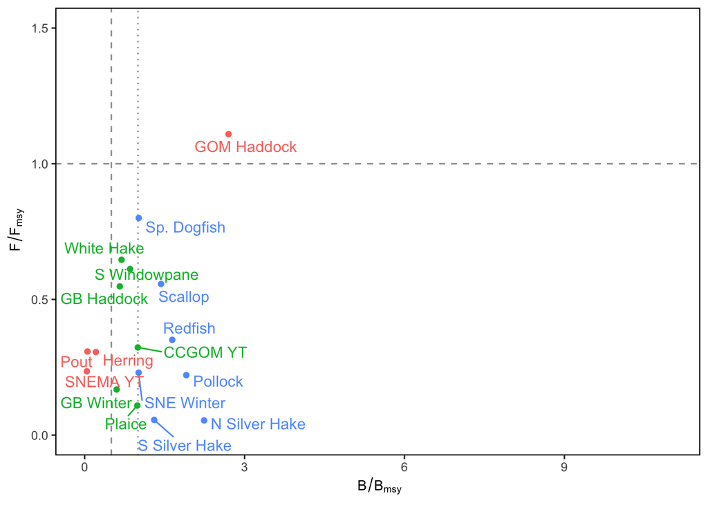

```r
stock_status <- stock_status_stockSMART %>%
  mutate(Code = recode(Code, "Dogfish" = "Sp. Dogfish" )) %>%
  spread(.,Var,Value) %>%
  filter(Council %in% c("NEFMC","Both")) %>%
  group_by(Stock) %>%
  mutate(score = case_when(
    (B.Bmsy <0.5) ~"a",
    (F.Fmsy >1) ~ "a",
    (F.Fmsy < 1 & B.Bmsy > 0.5 & B.Bmsy < 1) ~ "b",
    (F.Fmsy < 1 & B.Bmsy > 1) ~ "c"))
#Plot constants
y.max <- 1.5
x.max <- 10
all_missing <- stock_status %>%
  filter(is.na(B.Bmsy),is.na(F.Fmsy)) %>%
  dplyr::select(Code, Council)
b_missing <- stock_status %>%
  filter(is.na(B.Bmsy), !is.na(F.Fmsy)) %>%
  dplyr::select(Code, Council)
f_missing <- stock_status %>%
  filter(is.na(F.Fmsy), !is.na(B.Bmsy)) %>%
  dplyr::select(Code, Council)
#A dataframe that defines custom legend for stocks with unknown status
# all.df <- data.frame(text = all_missing$Code,
#                     x = rep(x.max*0.9,length(all_missing$Code)),
#                     #y = seq(1.45,1.05, length.out = 7))
#                     y = seq(1.45,1.05, length.out = length(all_missing$Code)))
# b.df <- data.frame(text = b_missing$Code,
#                     x = rep(x.max*0.7,length(b_missing$Code)),
#                     y = c(1.45,2.15, length.out = length(b_missing$Code)))
# f.df <- data.frame(text = f_missing$Code,
#                     x = rep(x.max*0.5,length(f_missing$Code)),
#                     y = seq(1.45,1.0, length.out = length(f_missing$Code)))

# Custom Color
custom_color<- c("#56B4E9", "#009E73", "#0072B2")

#Plotting code
ggplot(data = stock_status) +
  geom_vline(xintercept = 1, linetype = "dotted", color = "grey60")+
  geom_vline(xintercept = 0.5, linetype = "dashed", color = "grey60")+
  geom_hline(yintercept = 1, linetype = "dashed", color = "grey60") +
  geom_point(aes(x = B.Bmsy,
                 y = F.Fmsy,
                 color = stock_status$score)) +
  geom_text_repel(aes(x = B.Bmsy, #geom_text_repel auto-jitters text around points
                      y = F.Fmsy,
                      label = Code,
                      color = stock_status$score), show.legend = FALSE,nudge_y = -0.01, nudge_x = 0.05) +
  ylim(0,y.max) +
  xlim(0,x.max*1.1) +
  # geom_text(data = all.df, aes(x = x, y = y, label = text),show.legend = FALSE, size = 3)+
  # geom_text(data = b.df, aes(x = x, y = y, label = text),show.legend = FALSE, size = 3)+
  # geom_text(data = f.df, aes(x = x, y = y, label = text),show.legend = FALSE, size = 3)+
  # scale_color_brewer(palette = "Dark2", #Change legend labels for clarity
  #                    breaks = stock_status$score) +
  # annotate("rect", xmin = 0.924*x.max,
  #          xmax = 1.08*x.max,
  #          ymin = 0.645*y.max,
  #          ymax = 0.98*y.max,
  #          alpha = 0.01) +
  # annotate("text", x = 9, y = 1.5, label = "F and B missing", fontface =2, size = 3)+
  # annotate("rect",
  #            xmin = 0.70*x.max,
  #            xmax = 0.85*x.max,
  #            ymin = 0.90*y.max,
  #            ymax = 1.8,
  #            alpha = 0.01) +
  # annotate("text", x = 7, y = 1.5, label = "B missing", fontface =2, size = 3)+
  # annotate("rect", xmin = 0.509*x.max,
  #          xmax = 0.681*x.max,
  #          ymin = 0.65*y.max,
  #          ymax = 0.98*y.max,
  #          alpha = 0.01) +
  # annotate("text", x = 5, y = 1.5, label = "F missing", fontface =2, size = 3)+
  xlab(expression(~B/B[msy])) +
  ylab(expression(~F/F[msy])) +
  guides(color = FALSE) +
  theme_ts()
```

#### SOE 2023 ecodata source, New England

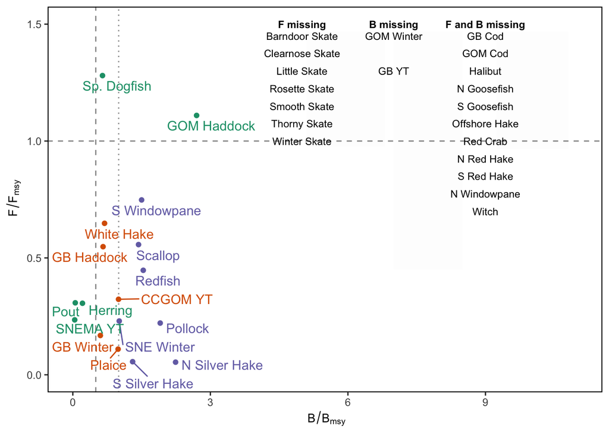

```r
#Get data, spread for plotting, and filter
stock_status <- ecodata::stock_status %>%
  dplyr::mutate(Code = dplyr::recode(Code, "Dogfish" = "Sp. Dogfish" )) %>%
  tidyr::spread(.,Var,Value) %>%
  dplyr::filter(Council %in% c("NEFMC","Both")) %>%
  dplyr::group_by(Stock) %>%
  dplyr::mutate(score = case_when(
    (B.Bmsy <0.5) ~"a",
    (F.Fmsy >1) ~ "a",
    (F.Fmsy < 1 & B.Bmsy > 0.5 & B.Bmsy < 1) ~ "b",
    (F.Fmsy < 1 & B.Bmsy > 1) ~ "c"))
#Plot constants
y.max <- 1.5
x.max <- 10
all_missing <- stock_status %>%
  dplyr::filter(is.na(B.Bmsy),is.na(F.Fmsy)) %>%
  dplyr::select(Code, Council)
b_missing <- stock_status %>%
  dplyr::filter(is.na(B.Bmsy), !is.na(F.Fmsy)) %>%
  dplyr::select(Code, Council)
f_missing <- stock_status %>%
  dplyr::filter(is.na(F.Fmsy), !is.na(B.Bmsy)) %>%
  dplyr::select(Code, Council)
#A dataframe that defines custom legend for stocks with unknown status
all.df <- data.frame(text = all_missing$Code,
                    x = rep(x.max*0.9,length(all_missing$Code)),
                    y = seq(1.45,0.7, length.out = length(all_missing$Code)))
b.df <- data.frame(text = b_missing$Code,
                    x = rep(x.max*0.7,length(b_missing$Code)),
                    y = seq(1.45,1.30, length.out = length(b_missing$Code)))
f.df <- data.frame(text = f_missing$Code,
                    x = rep(x.max*0.5,length(f_missing$Code)),
                    y = seq(1.45,1, length.out = length(f_missing$Code)))

#Plotting code
ggplot2::ggplot(data = stock_status) +
  ggplot2::geom_vline(xintercept = 1, linetype = "dotted", color = "grey60")+
  ggplot2::geom_vline(xintercept = 0.5, linetype = "dashed", color = "grey60")+
  ggplot2::geom_hline(yintercept = 1, linetype = "dashed", color = "grey60") +
  ggplot2::geom_point(aes(x = B.Bmsy,
                 y = F.Fmsy,
                 color = stock_status$score)) +
  ggrepel::geom_text_repel(aes(x = B.Bmsy, #geom_text_repel auto-jitters text around points
                      y = F.Fmsy,
                      label = Code,
                      color = stock_status$score), show.legend = FALSE,nudge_y = -0.01, nudge_x = 0.05) +
  ggplot2::ylim(0,y.max) +
  ggplot2::xlim(0,x.max*1.1) +
  ggplot2::geom_text(data = all.df, aes(x = x, y = y, label = text),show.legend = FALSE, size = 3)+
  ggplot2::geom_text(data = b.df, aes(x = x, y = y, label = text),show.legend = FALSE, size = 3)+
  ggplot2::geom_text(data = f.df, aes(x = x, y = y, label = text),show.legend = FALSE, size = 3)+
  ggplot2::scale_color_brewer(palette = "Dark2", #Change legend labels for clarity
                     breaks = stock_status$score) +
  ggplot2::annotate("rect", xmin = 0.924*x.max,
           xmax = 1.08*x.max,
           ymin = 0.645*y.max,
           ymax = 0.98*y.max,
           alpha = 0.01) +
  ggplot2::annotate("text", x = 9, y = 1.5, label = "F and B missing", fontface =2, size = 3)+
  ggplot2::annotate("rect",
             xmin = 0.70*x.max,
             xmax = 0.85*x.max,
             ymin = 0.30*y.max,
             ymax = 0.98*y.max,
             alpha = 0.01) +
  ggplot2::annotate("text", x = 7, y = 1.5, label = "B missing", fontface =2, size = 3)+
  ggplot2::annotate("rect", xmin = 0.509*x.max,
           xmax = 0.681*x.max,
           ymin = 0.65*y.max,
           ymax = 0.98*y.max,
           alpha = 0.01) +
  ggplot2::annotate("text", x = 5, y = 1.5, label = "F missing", fontface =2, size = 3)+
  ggplot2::xlab(expression(~B/B[msy])) +
  ggplot2::ylab(expression(~F/F[msy])) +
  ggplot2::guides(color = FALSE) +
  ecodata::theme_ts()
```

### Issues

None noted, stockSMART and `stocksmart` have been updated as of December 13 2023.